# Real-world Data Wrangling

In this project, I applied the skills that acquired in the course to gather and wrangle real-world data with two datasets.

I embarked on an exciting data analytics journey, focusing on two different data sets: one from UCI's machine learning repository and one from Kaggle.

## 1. Gather Data

### **1.1.** Problem Statement

- Google Dataset Search https://datasetsearch.research.google.com/
- The U.S. Government’s open data https://data.gov/
- UCI Machine Learning Repository https://archive.ics.uci.edu/ml/index.php

```python
# Import the numpy library
import numpy as np

# Import the pandas library
import pandas as pd

# Import the matplotlib library
from matplotlib import pyplot as plt

# Import the zipfile library
import zipfile

# Import the os library
import os

# Import the seaborn library
import seaborn as sns

# Ensurethat matplotlib plots display inline within Jupyter Notebooks
%matplotlib inline
```

#### Data Set1:

-> Type: CSV File.

-> Method: The data was gathered using the "Downloading files" method from https://archive.ics.uci.edu/ source.)

-> Dataset variables:

- age: Age of the individual.
- workclass: The type of work the individual is engaged in (e.g., private, self-employed, government).
- fnlwgt: Final weight assigned to each individual in the dataset.
- education: Highest level of education
- education-num: Number of years of education
- marital-status: Marital status of the individual (e.g., married, single, divorced).
- relationship: Relationship status(e.g., husband, wife, own-child, Not-in-family, Unmarried, etc).
- race: (e.g., White, Black, Asian-Pac-Islander, Amer-Indian-Eskimo)
- sex: Gender (e.g., Male, Female).
- capital-gain: Capital gains
- capital-loss: Capital-loss
- hours-per-week: Number of hours worked per week.
- native-country: Country of origin of the individual.
- annual_income: Annual income (e.g., <=50K, >50K).

```python
# Load the dataset
df1 = pd.read_csv('census-income.csv')
# Display the first 10 rows
print(df1.head(10))
```

```
   age         workclass  fnlwgt  education  education-num  \
0   39         State-gov   77516  Bachelors             13
1   50  Self-emp-not-inc   83311  Bachelors             13
2   38           Private  215646    HS-grad              9
3   53           Private  234721       11th              7
4   28           Private  338409  Bachelors             13
5   37           Private  284582    Masters             14
6   49           Private  160187        9th              5
7   52  Self-emp-not-inc  209642    HS-grad              9
8   31           Private   45781    Masters             14
9   42           Private  159449  Bachelors             13

          marital-status         occupation   relationship   race     sex  \
0          Never-married       Adm-clerical  Not-in-family  White    Male
1     Married-civ-spouse    Exec-managerial        Husband  White    Male
```

[output cut: 20 more lines]

```python
# Basic info about the DataFrame
df1.info()
print('<----------------->')
# Check for missing values
print(df1.isnull().sum())
```

```
<class 'pandas.core.frame.DataFrame'>
RangeIndex: 32561 entries, 0 to 32560
Data columns (total 15 columns):
 #   Column          Non-Null Count  Dtype
---  ------          --------------  -----
 0   age             32561 non-null  int64
 1   workclass       32561 non-null  object
 2   fnlwgt          32561 non-null  int64
 3   education       32561 non-null  object
 4   education-num   32561 non-null  int64
 5   marital-status  32561 non-null  object
 6   occupation      32561 non-null  object
 7   relationship    32561 non-null  object
 8   race            32561 non-null  object
 9   sex             32561 non-null  object
 10  capital-gain    32561 non-null  int64
 11  capital-loss    32561 non-null  int64
 12  hours-per-week  32561 non-null  int64
 13  native-country  32561 non-null  object
 14  annual_income   32561 non-null  object
dtypes: int64(6), object(9)
memory usage: 3.7+ MB
<----------------->
age               0
workclass         0
fnlwgt            0
education         0
education-num     0
marital-status    0
occupation        0
relationship      0
race              0
sex               0
capital-gain      0
capital-loss      0
hours-per-week    0
native-country    0
annual_income     0
dtype: int64
```

```python
# Descriptive statistics
print(df1.describe())
```

```
                age        fnlwgt  education-num  capital-gain  capital-loss  \
count  32561.000000  3.256100e+04   32561.000000  32561.000000  32561.000000
mean      38.581647  1.897784e+05      10.080679   1077.648844     87.303830
std       13.640433  1.055500e+05       2.572720   7385.292085    402.960219
min       17.000000  1.228500e+04       1.000000      0.000000      0.000000
25%       28.000000  1.178270e+05       9.000000      0.000000      0.000000
50%       37.000000  1.783560e+05      10.000000      0.000000      0.000000
75%       48.000000  2.370510e+05      12.000000      0.000000      0.000000
max       90.000000  1.484705e+06      16.000000  99999.000000   4356.000000

       hours-per-week
count    32561.000000
mean        40.437456
std         12.347429
min          1.000000
25%         40.000000
50%         40.000000
75%         45.000000
max         99.000000
```

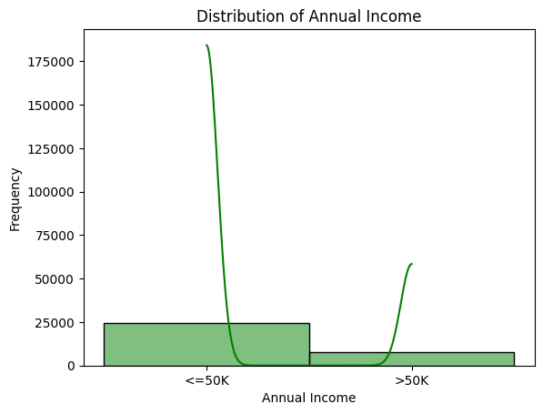

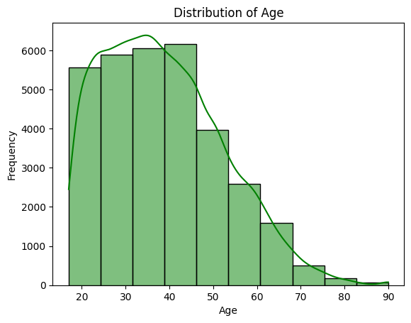

```python
import matplotlib.pyplot as plt
import seaborn as sns

# Plot the distribution of Annual Income with green color
sns.histplot(df1['annual_income'], bins=30, kde=True, color='green')
plt.title('Distribution of Annual Income')
plt.xlabel('Annual Income')
plt.ylabel('Frequency')
plt.show()

# Plot the distribution of Age with green color
sns.histplot(df1['age'], bins=10, kde=True, color='green')
plt.title('Distribution of Age')
plt.xlabel('Age')
plt.ylabel('Frequency')
plt.show()
```

```python
# Check for invalid values in 'age'
invalid_ages = df1[df1['age'] < 0]
print(f"Invalid ages found: {invalid_ages}")
```

```
Invalid ages found: Empty DataFrame
Columns: [age, workclass, fnlwgt, education, education-num, marital-status, occupation, relationship, race, sex, capital-gain, capital-loss, hours-per-week, native-country, annual_income]
Index: []
```